# STAT 184 Final Project

Gavin Crowley and Alex Bechakas

2024-04-28

The code style that we chose was BigCamelCase.

# Topic

For our project, we are using two NFL Data sets. We chose to have our project be about NFL data because we are both sports fans and specifically big NFL fans and we are both interested in the overall breakdown of statistics in football.

# Investigation

### For the defense data, we are investigating:

How each statistic varies by position?

What positions lead in what stats?

### For the Quarterback data, we are investigating:

How do Quarterbacks stats compare between eras?

What Quarterback had the best season?

# Defense Data Set

This data set is from Pro Football Reference. The purpose of this data set is that it contains the defensive statistics for all players who recorded at least 1 defensive stat in the 2023/24 NFL Season. A case in this data set is a individual player. Our analysis of the defense data set will focus on most of the attributes. Those attributes include: Position, G, GS, Int, TD, PD, FF, FR, Sk, Comb, Solo, Ast, TFL, QBHits, and Sfty.

```r
# Import data set
DefenseStats <- read_excel("2023 NFL Defense Stats.xlsx")
View(DefenseStats)
```

# Defense Data Set Wrangling

Selected the columns from the data set we were interested in using excluding columns like player name, team, and return yards as those were not needed. Filtered the position column to only include defensive positions and not include offensive positions. Grouped all the data by position so the table would have one row for each position and the entries in each column would be the total stats for all players in that position.

```r
DefS <- DefenseStats %>%
  # Select wanted statistics
  select(Position,G,GS,Int,TD,PD,FF,FR,Sk,Comb,Solo,Ast,TFL,QBHits, Sfty)
# Select defensive positions so the offensive positions are not included
DefS <- DefS %>% filter (Position %in% c("DT", "DE", "LB", "CB", "S"))
# Group by position
DefS <- DefS %>% group_by(Position) %>%
  # Creates totals of each stat for each position
  summarize(
    Games = sum(G),
    Games_Started = sum(GS),
    Interceptions = sum(Int),
    Touchdowns = sum(TD),
    Pass_Deflections = sum(PD),
    Forced_Fumbles = sum(FF),
    Fumble_Recoveries = sum(FR),
    Sacks = sum(Sk),
    Combined_Tackles = sum(Comb),
    Solo_Tackles = sum(Solo),
    Assisted_Tackles = sum(Ast),
    Tackles_For_Loss = sum(TFL),
    QB_Hits = sum(QBHits),
    Safeties = sum(Sfty), .groups = "drop"

  )
```

# Defense Data Table

```r
# Data table
DefS %>%
  kable(
    # Title
    caption = "Statistic Totals for Each NFL Position",
    booktabs = TRUE,
    # Alignment
    align = rep("c", 11)
  ) %>%
  kable_styling(
    # Table style
    bootstrap_options = c("striped"),
    # Font size
    font_size = 16
  )
```

Statistic Totals for Each NFL Position

| Position | Games | Games_Started | Interceptions | Touchdowns | Pass_Deflections | Forced_Fumbles | Fumble_Recoveries | Sacks | Combined_Tackles | Solo_Tackles | Assisted_Tackles | Tackles_For_Loss | QB_Hits | Safeties |
| --- | --- | --- | --- | --- | --- | --- | --- | --- | --- | --- | --- | --- | --- | --- |
| CB | 3086 | 1482 | 190 | 26 | 1163 | 89 | 67 | 43.0 | 8270 | 6213 | 2057 | 297 | 100 | 1 |
| DE | 1211 | 515 | 2 | 1 | 104 | 50 | 25 | 329.5 | 2399 | 1420 | 979 | 429 | 730 | 1 |
| DT | 2508 | 1275 | 10 | 6 | 208 | 57 | 59 | 392.5 | 5047 | 2646 | 2401 | 641 | 1046 | 3 |
| LB | 3772 | 1670 | 78 | 18 | 461 | 153 | 106 | 567.0 | 12336 | 7523 | 4813 | 1056 | 1166 | 2 |
| S | 1810 | 1034 | 149 | 12 | 466 | 70 | 50 | 63.0 | 6719 | 4569 | 2150 | 225 | 128 | 0 |

For this data table, each row is a different position. Each column is a different stat and the entries are the total of that recorded stat for all players of that position.

# Defense Data Visualizations

For the Defense Data, we created 14 data visualizations. Each data visualization has position as the x-axis and the stat as the y-axis. Each data visualization shows which position leads in that statistic.

## Games Graph

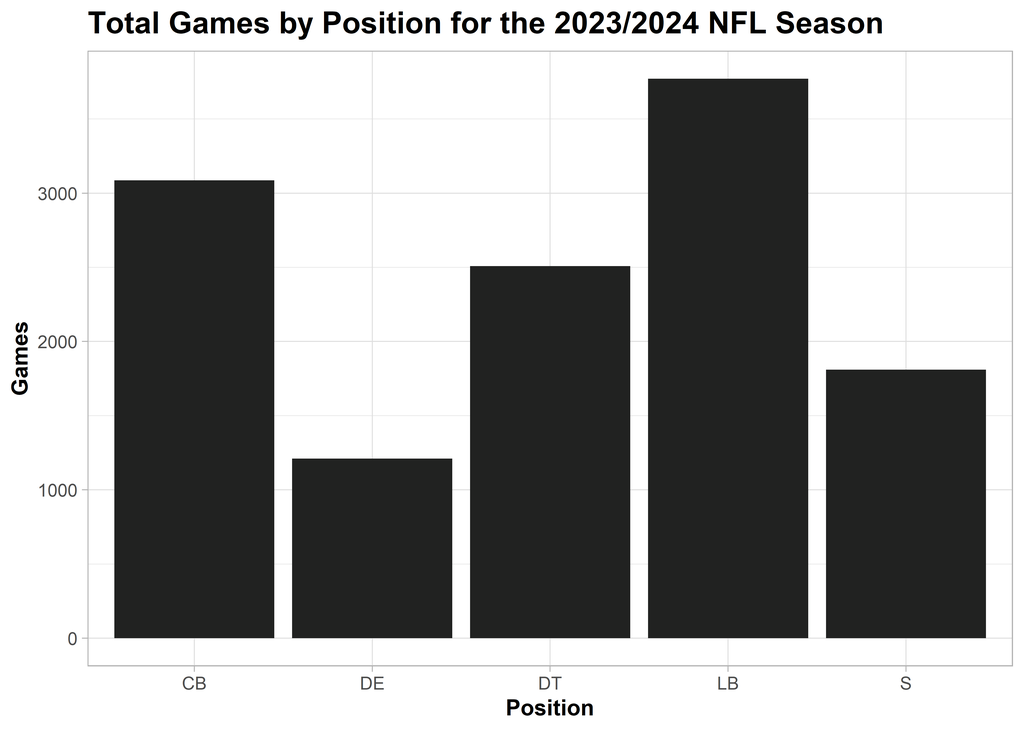

```r
ggplot(DefS) +
  # Variables
  aes(x = Position, y = Games) +
  # Bar color
  geom_col(fill = "#212221") +
  # Labels
  labs(
    x = "Position",
    y = "Games",
    title = "Total Games by Position for the 2023/2024 NFL Season"
  ) +
  # Theme
  theme_light() +
  theme(
    plot.title = element_text(size = 15L,
                              face = "bold"),
    axis.title.y = element_text(face = "bold"),
    axis.title.x = element_text(face = "bold")
  )
```

This graph shows that linebackers lead in games played and defensive ends have the least games played.

## Games Started Graph

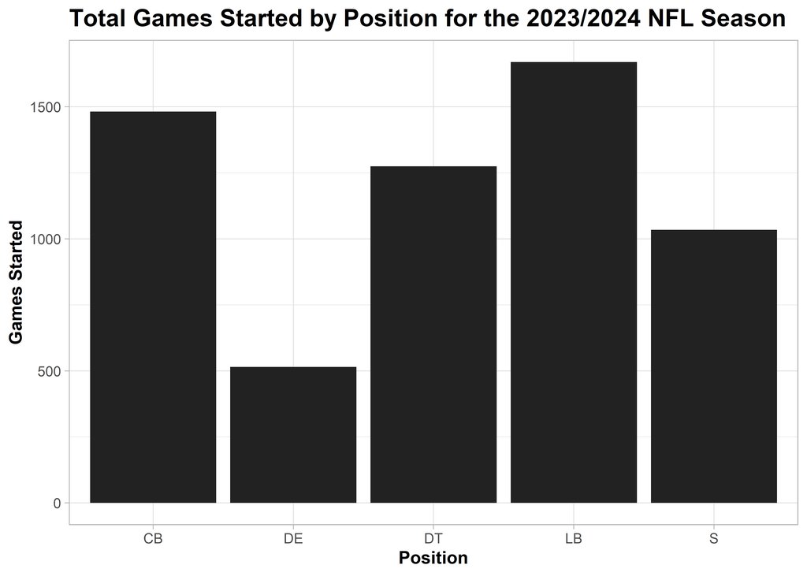

```r
ggplot(DefS) +
  aes(x = Position, y = Games_Started) +
  geom_col(fill = "#212221") +
  labs(
    x = "Position",
    y = "Games Started",
    title = "Total Games Started by Position for the 2023/2024 NFL Season"
  ) +
  theme_light() +
  theme(
    plot.title = element_text(size = 15L,
                              face = "bold"),
    axis.title.y = element_text(face = "bold"),
    axis.title.x = element_text(face = "bold")
  )
```

This graph shows that linebackers lead in games started and defensive ends have the least games started.

## Interceptions Graph

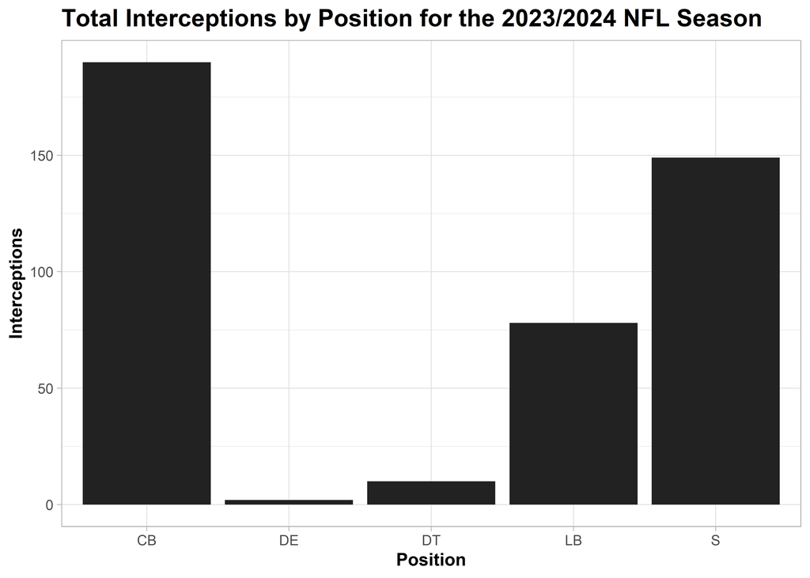

```r
ggplot(DefS) +
  aes(x = Position, y = Interceptions) +
  geom_col(fill = "#212221") +
  labs(
    x = "Position",
    y = "Interceptions",
    title = "Total Interceptions by Position for the 2023/2024 NFL Season"
  ) +
  theme_light() +
  theme(
    plot.title = element_text(size = 15L,
                              face = "bold"),
    axis.title.y = element_text(face = "bold"),
    axis.title.x = element_text(face = "bold")
  )
```

This graph shows that corner backs lead in interceptions and defensive ends have the least interceptions.

## Touchdowns Graph

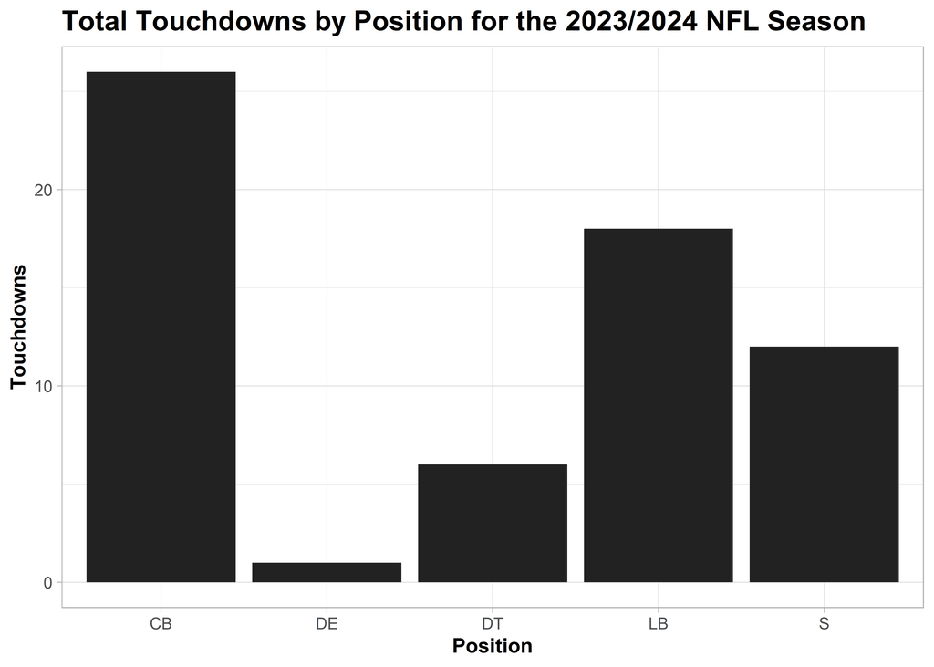

```r
ggplot(DefS) +
  aes(x = Position, y = Touchdowns) +
  geom_col(fill = "#212221") +
  labs(
    x = "Position",
    y = "Touchdowns",
    title = "Total Touchdowns by Position for the 2023/2024 NFL Season"
  ) +
  theme_light() +
  theme(
    plot.title = element_text(size = 15L,
                              face = "bold"),
    axis.title.y = element_text(face = "bold"),
    axis.title.x = element_text(face = "bold")
  )
```

This graph shows that corner backs lead in touchdowns and defensive ends have the least touchdowns.

## Pass Deflections Graph

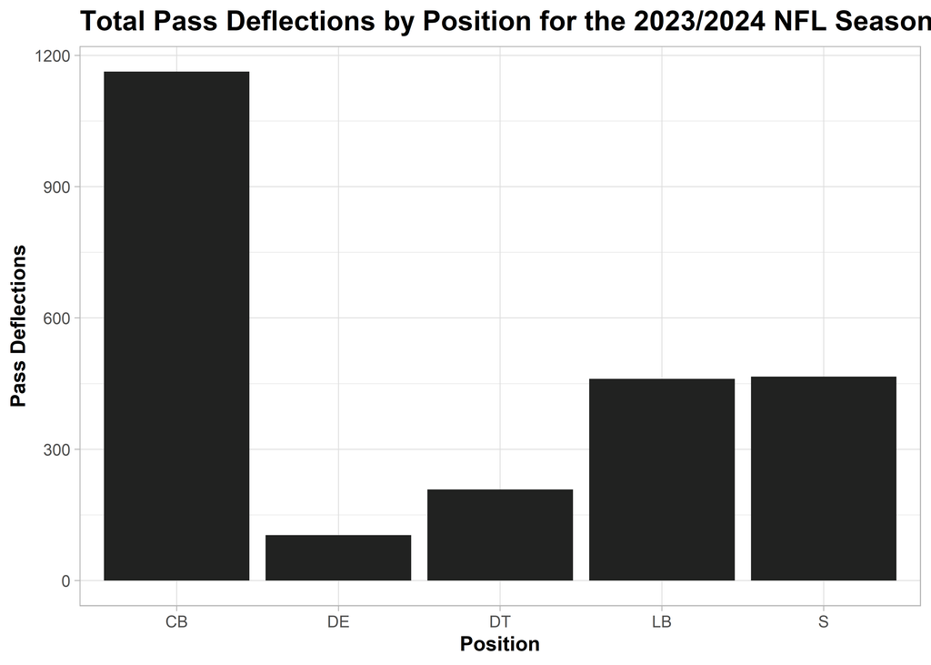

```r
ggplot(DefS) +
  aes(x = Position, y = Pass_Deflections) +
  geom_col(fill = "#212221") +
  labs(
    x = "Position",
    y = "Pass Deflections",
    title = "Total Pass Deflections by Position for the 2023/2024 NFL Season"
  ) +
  theme_light() +
  theme(
    plot.title = element_text(size = 15L,
                              face = "bold"),
    axis.title.y = element_text(face = "bold"),
    axis.title.x = element_text(face = "bold")
  )
```

This graph shows that corner backs lead in pass deflections and defensive ends have the least pass deflections.

## Forced Fumbles Graph

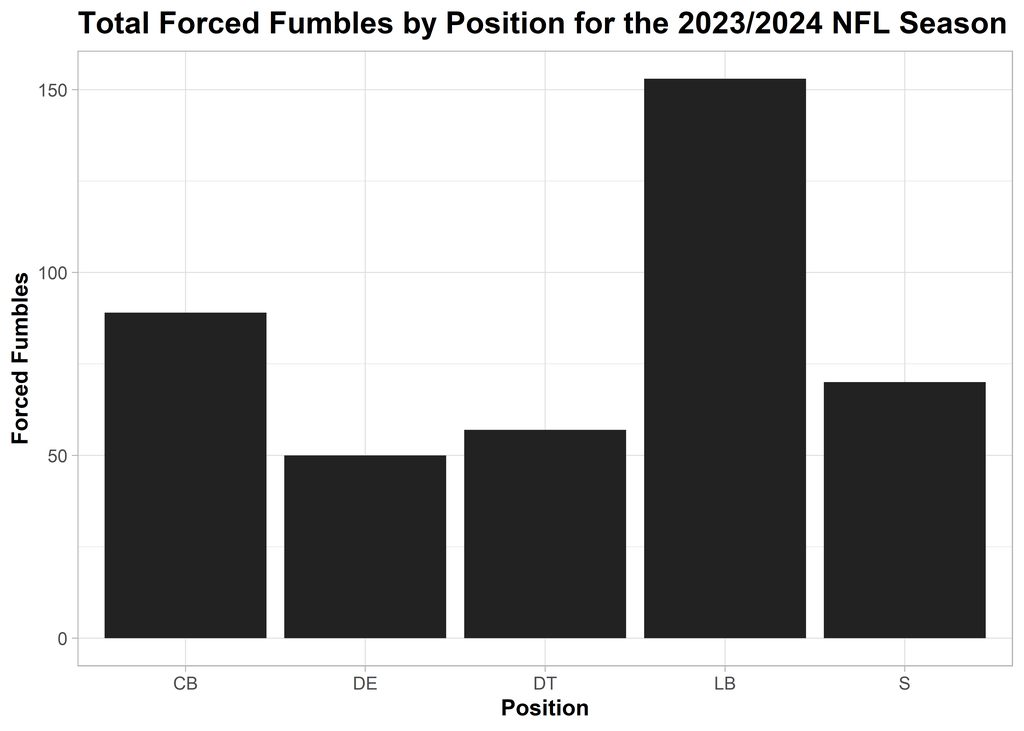

```r
ggplot(DefS) +
  aes(x = Position, y = Forced_Fumbles) +
  geom_col(fill = "#212221") +
  labs(
    x = "Position",
    y = "Forced Fumbles",
    title = "Total Forced Fumbles by Position for the 2023/2024 NFL Season"
  ) +
  theme_light() +
  theme(
    plot.title = element_text(size = 15L,
                              face = "bold"),
    axis.title.y = element_text(face = "bold"),
    axis.title.x = element_text(face = "bold")
  )
```

This graph shows that linebackers lead in forced fumbles and defensive ends have the least forced fumbles.

## Fumble Recoveries Graph

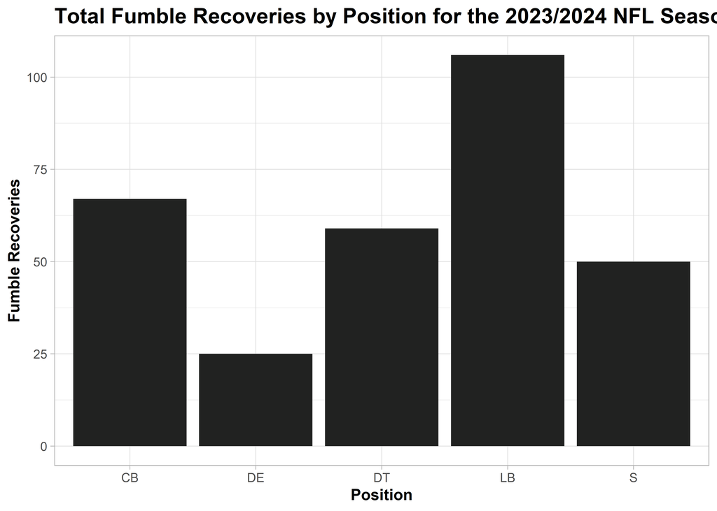

```r
ggplot(DefS) +
  aes(x = Position, y = Fumble_Recoveries) +
  geom_col(fill = "#212221") +
  labs(
    x = "Position",
    y = "Fumble Recoveries",
    title = "Total Fumble Recoveries by Position for the 2023/2024 NFL Season"
  ) +
  theme_light() +
  theme(
    plot.title = element_text(size = 15L,
                              face = "bold"),
    axis.title.y = element_text(face = "bold"),
    axis.title.x = element_text(face = "bold")
  )
```

This graph shows that linebackers lead in fumble recoveries and defensive ends have the least fumble recoveries.

## Sacks Graph

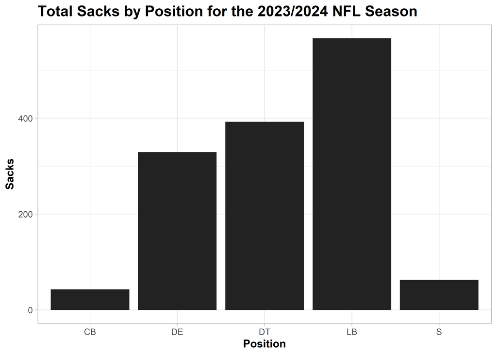

```r
ggplot(DefS) +
  aes(x = Position, y = Sacks) +
  geom_col(fill = "#212221") +
  labs(
    x = "Position",
    y = "Sacks",
    title = "Total Sacks by Position for the 2023/2024 NFL Season"
  ) +
  theme_light() +
  theme(
    plot.title = element_text(size = 15L,
                              face = "bold"),
    axis.title.y = element_text(face = "bold"),
    axis.title.x = element_text(face = "bold")
  )
```

This graph shows that linebackers lead in sacks and corner backs have the least sacks.

## Combined Tackles Graph

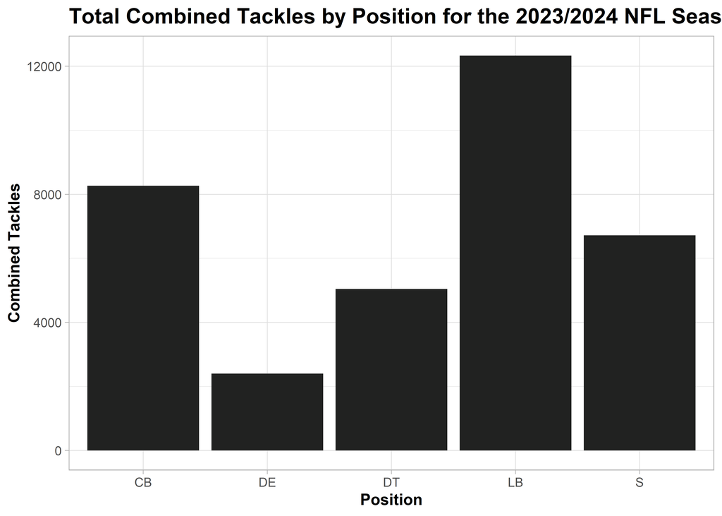

```r
ggplot(DefS) +
  aes(x = Position, y = Combined_Tackles) +
  geom_col(fill = "#212221") +
  labs(
    x = "Position",
    y = "Combined Tackles",
    title = "Total Combined Tackles by Position for the 2023/2024 NFL Season"
  ) +
  theme_light() +
  theme(
    plot.title = element_text(size = 15L,
                              face = "bold"),
    axis.title.y = element_text(face = "bold"),
    axis.title.x = element_text(face = "bold")
  )
```

This graph shows that linebackers lead in combined tackles and defensive ends have the least combined tackles.

## Solo Tackles Graph

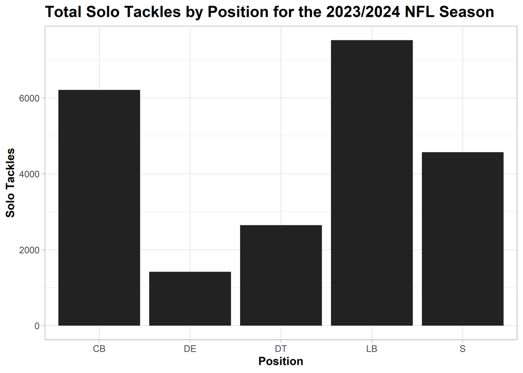

```r
ggplot(DefS) +
  aes(x = Position, y = Solo_Tackles) +
  geom_col(fill = "#212221") +
  labs(
    x = "Position",
    y = "Solo Tackles",
    title = "Total Solo Tackles by Position for the 2023/2024 NFL Season"
  ) +
  theme_light() +
  theme(
    plot.title = element_text(size = 15L,
                              face = "bold"),
    axis.title.y = element_text(face = "bold"),
    axis.title.x = element_text(face = "bold")
  )
```

This graph shows that linebackers lead in solo tackles and defensive ends have the least solo tackles.

## Assisted Tackles Graph

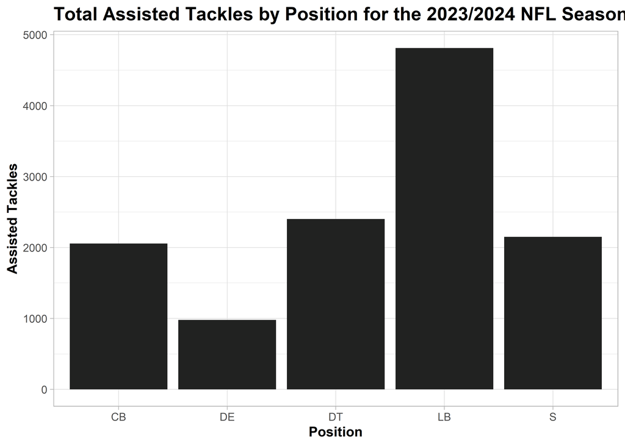

```r
ggplot(DefS) +
  aes(x = Position, y = Assisted_Tackles) +
  geom_col(fill = "#212221") +
  labs(
    x = "Position",
    y = "Assisted Tackles",
    title = "Total Assisted Tackles by Position for the 2023/2024 NFL Season"
  ) +
  theme_light() +
  theme(
    plot.title = element_text(size = 15L,
                              face = "bold"),
    axis.title.y = element_text(face = "bold"),
    axis.title.x = element_text(face = "bold")
  )
```

This graph shows that linebackers lead in assisted tackles and defensive ends have the least assisted tackles.

## Tackles For Loss Graph

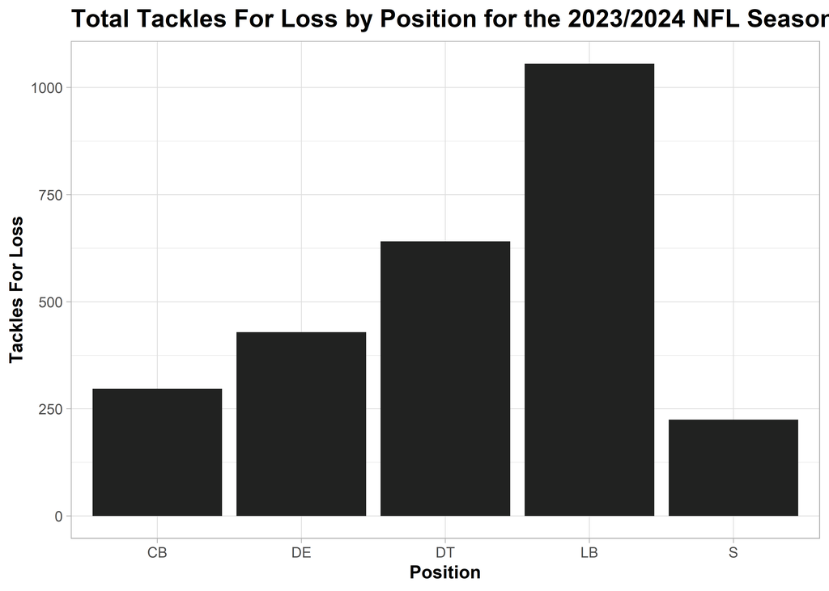

```r
ggplot(DefS) +
  aes(x = Position, y = Tackles_For_Loss) +
  geom_col(fill = "#212221") +
  labs(
    x = "Position",
    y = "Tackles For Loss",
    title = "Total Tackles For Loss by Position for the 2023/2024 NFL Season"
  ) +
  theme_light() +
  theme(
    plot.title = element_text(size = 15L,
                              face = "bold"),
    axis.title.y = element_text(face = "bold"),
    axis.title.x = element_text(face = "bold")
  )
```

This graph shows that linebackers lead in tackles for loss and safeties have the least tackles for loss.

## QB Hits Graph

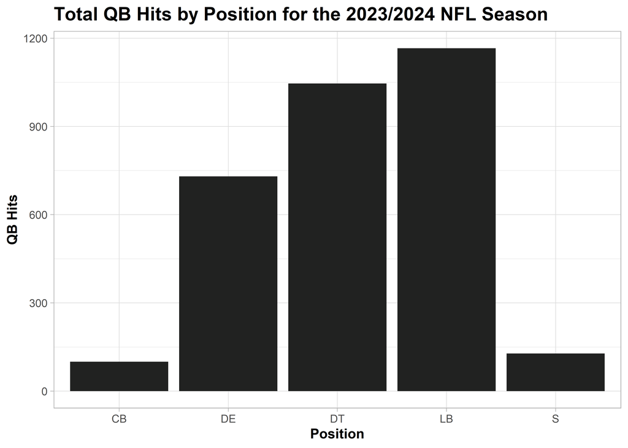

```r
ggplot(DefS) +
  aes(x = Position, y = QB_Hits) +
  geom_col(fill = "#212221") +
  labs(
    x = "Position",
    y = "QB Hits",
    title = "Total QB Hits by Position for the 2023/2024 NFL Season"
  ) +
  theme_light() +
  theme(
    plot.title = element_text(size = 15L,
                              face = "bold"),
    axis.title.y = element_text(face = "bold"),
    axis.title.x = element_text(face = "bold")
  )
```

This graph shows that linebackers lead in quarter back hits and corner backs have the least quarter back hits.

## Safeties Graph

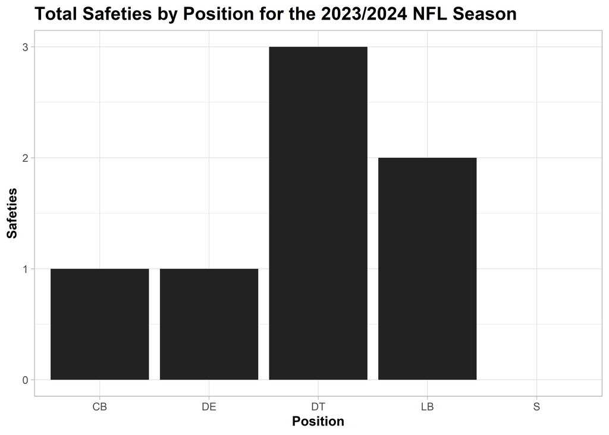

```r
ggplot(DefS) +
  aes(x = Position, y = Safeties) +
  geom_col(fill = "#212221") +
  labs(
    x = "Position",
    y = "Safeties",
    title = "Total Safeties by Position for the 2023/2024 NFL Season"
  ) +
  theme_light() +
  theme(
    plot.title = element_text(size = 15L,
                              face = "bold"),
    axis.title.y = element_text(face = "bold"),
    axis.title.x = element_text(face = "bold")
  )
```

This graph shows that defensive tackles lead in safeties and safeties have the least safeties.

Overall, linebackers lead in most of the statistics and defensive ends have the least of most statistics. This makes sense as linebackers have the most games played and started and defensive ends have the least.

# Quarterback Data Set

This data set is from kaggle, and is every Quarterback season from 1970 to 2022. It shows different stats from the season including Passing Yards, Touchdowns, and Interceptions. However, there are many more stats included in the table that I did not feel were important for comparison.

```r
Stats <- read_excel("NFL QB Stats.xlsx")
View(Stats)
```

# Quarterback Data Set Wrangling

For the Quarterbacks table there was quite a bit of wrangling of all sorts done. I began by selecting the top 20 quarterbacks by passing yards per year to factor out human variability, and Quarterback injuries during the season. Then the rest of the wrangling is separated into two categories, Yards and Points.

```r
#Takes top 20 QBs by year
Starters <- Stats%>%
  group_by(Year)%>%
  arrange(desc(`Pass Yds`))%>%
  filter(row_number()<21)%>%
  arrange(desc(Year))
```

## Yards Wrangling

Many people discuss greatness of a Quarterbacks by putting most of their emphasis on the yards the Quarterback threw for. The first wrangling I did for the yards was create an average passing yards per year and merged the table onto the previously starters table. I then added the number of games played in a year, because since 1970 the number of games played in a year has changed twice, and that knowledge is necessary for comparisons. After adding the statistics for clarification, the main stat of Average Passing Yards+, a standardized statistic for passing yars per year, is created and added onto the starters table.

```r
#Gets a table of yearly avergae passing yards
Era<- Starters%>%
  group_by(Year)%>%
  filter(Year != 1982)%>%
  summarise(`Year Mean` = mean(`Pass Yds`))
#Adds number of games to seasons
Temp<-Era%>%
  mutate(`Games per Year` = if_else(Year<1982,"14 Games","16 Games"))
Temp2<-replace(Temp$`Games per Year`,Temp$Year>2020,"17 Games")
# Adds the number of games to Era
NewEra<-Era%>%
  mutate(`Games per Year` = Temp2)
#Merges the Era table to the starters table
MergedYards<-merge(x= Starters, y = Era, by = "Year", all.x = T)%>%
  select(Year,Player, `Pass Yds`, TD, INT, `Year Mean`)
#Creates the APY+ stats, and adds it to the table
AdjYards<- MergedYards%>%
  summarise(Year = as.character(Year), Player = Player, TD = TD, INT= INT,`APY (Average Passing Yards)` = `Year Mean` ,Yards = `Pass Yds`, `APY+` = round(100*(`Pass Yds`/`Year Mean`),0))%>%
arrange(desc(`APY+`))
```

## Points Wrangling

The points variable created is a better way to compare Quarterbacks over the years by more stats than just passing yards. For points, each yard is a point, each touchdown is 100 points, and each interception is -50 points. The rest of the steps of the points data wrangling is the exact same process as above, but rather than the main stat of comparison being the passing yards stat, it is for the newly created points stat.

```r
#Adds a points column to the starters table
Points<-Starters%>%
  group_by(Year)%>%
  reframe(Year = Year, Player = Player, Yards = `Pass Yds`,TD = TD, INT = INT, Points = ((`Pass Yds`)+(TD*100)-(INT*50)))
#Gets the yearly average for points
EraPoints<- Points%>%
  group_by(Year)%>%
  filter(Year != 1982)%>%
  summarise(`Year Mean` = mean(Points))
#Add the games per season to table
NewEraPoints<-EraPoints%>%
  mutate(`Games per Year` = Temp2)
#Adds the average points to the end of the points table
MergedPoints<-merge(x= Points, y = NewEraPoints, by = "Year", all.x = T)%>%
  select(Year,Player, Points, TD, INT, `Year Mean`,`Games per Year`)
#Creates the AP+ stat and final table
AdjPoints<- MergedPoints%>%
  summarise(Year = as.character(Year), Player = Player, TD = TD, INT =INT,`AP (Average Points)` = `Year Mean`
            ,Points = Points, `AP+` = round(100*(Points/`Year Mean`),0),`Games per Year`= `Games per Year`)%>%
  arrange(desc(`AP+`))
```

# Quarterback Data Tables

The created tables are the best era adjusted Quarterbacks of all time. I selected the top 5 based on the created Average Passing Yards+, APY+, and the Average Points+, AP+. The difference in the tables is the main reason why you cannot strictly focus on passing yards like some people in debates do. The top APY+ does not align with the top AP+ players showing the importance of the other stats that Quarterbacks have.

## Average Passing Yards+

```r
AdjYardTable<- AdjYards%>%
  select(Year, Player, TD, INT ,`APY+`)
head(AdjYardTable,5)%>%
  kable(caption = "Best APY+ since 1970",
        align = c("l", rep("c", 10))) %>%
  kable_styling(
    bootstrap_options = c("striped"),
    font_size = 16)
```

Best APY+ since 1970

| Year | Player | TD | INT | APY+ |
| --- | --- | --- | --- | --- |
| 1973 | Roman Gabriel | 23 | 12 | 172 |
| 1984 | Dan Marino | 48 | 17 | 158 |
| 1991 | Warren Moon | 23 | 21 | 150 |
| 1990 | Warren Moon | 33 | 13 | 149 |
| 1971 | John Hadl | 21 | 25 | 147 |

## Average Points+

```r
AdjPointTable<- AdjPoints%>%
  select(Year, Player, TD, INT ,`AP+`)
head(AdjPointTable,5)%>%
  kable(caption = "Best AP+ since 1970",
        align = c("l", rep("c", 10))) %>%
  kable_styling(
    bootstrap_options = c("striped"),
    font_size = 16)
```

Best AP+ since 1970

| Year | Player | TD | INT | AP+ |
| --- | --- | --- | --- | --- |
| 1984 | Dan Marino | 48 | 17 | 203 |
| 1973 | Roman Gabriel | 23 | 12 | 190 |
| 1986 | Dan Marino | 44 | 23 | 189 |
| 2007 | Tom Brady | 50 | 8 | 181 |
| 2013 | Peyton Manning | 55 | 10 | 176 |

# Quarterback Data Visualizations

The created visualizations can show why it is so difficult to compare players between eras, and can show who the most effective players were in the each statistical category. After that the best APY+ and AP+ players will be selected side by side in a bar plot and compared.

## Era comparisons

### Average yards per season

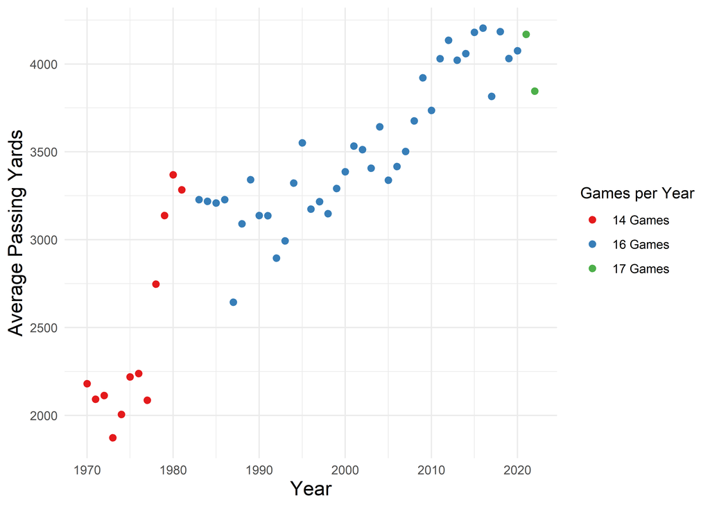

```r
#Creates APY+ plot
ggplot(NewEra) +
  aes(x = Year, y = `Year Mean`, colour = `Games per Year`) +
  geom_point(shape = "circle", size = 2L) +
  scale_color_brewer(palette = "Set1", direction = 1) +
  labs(x = "Year", y = "Average Passing Yards") +
  theme_minimal() +
  theme(
    plot.title = element_text(size = 30L,
                              hjust = 0.5),
    axis.title.y = element_text(size = 14L),
    axis.title.x = element_text(size = 14L)
  )
```

### Average points per season

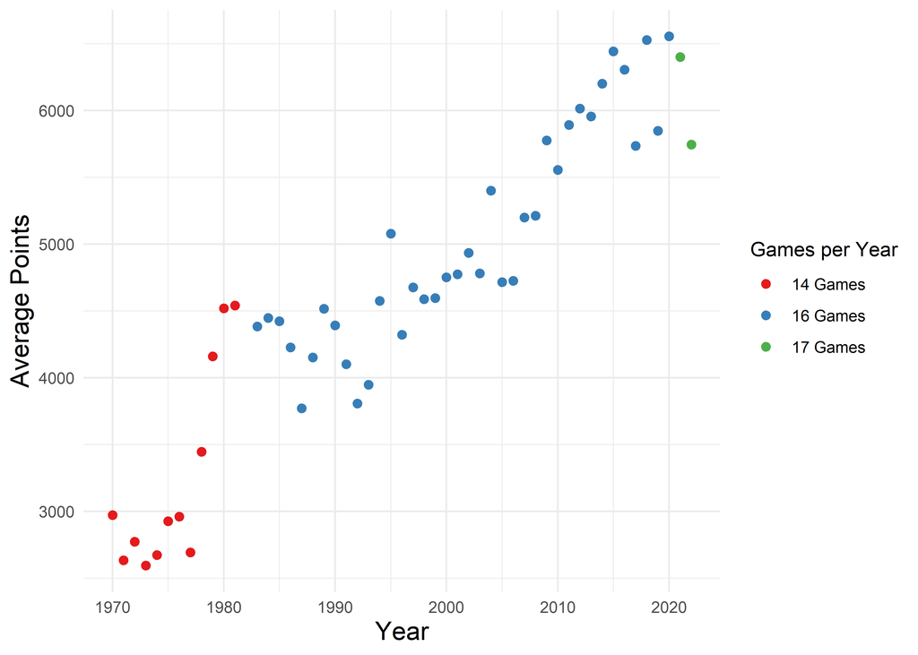

```r
#Creates AP+ per year plot
ggplot(NewEraPoints) +
  aes(x = Year, y = `Year Mean`, colour = `Games per Year`) +
  geom_point(shape = "circle", size = 2L) +
  scale_color_brewer(palette = "Set1", direction = 1) +
  labs(x = "Year", y = "Average Points") +
  theme_minimal() +
  theme(
    plot.title = element_text(size = 30L,
                              hjust = 0.5),
    axis.title.y = element_text(size = 14L),
    axis.title.x = element_text(size = 14L)
  )
```

## Best Players comparisons

These Data visualizations will take the Data Tables from above, and show the visualization through a bar plot.

### Average Passing Yards+

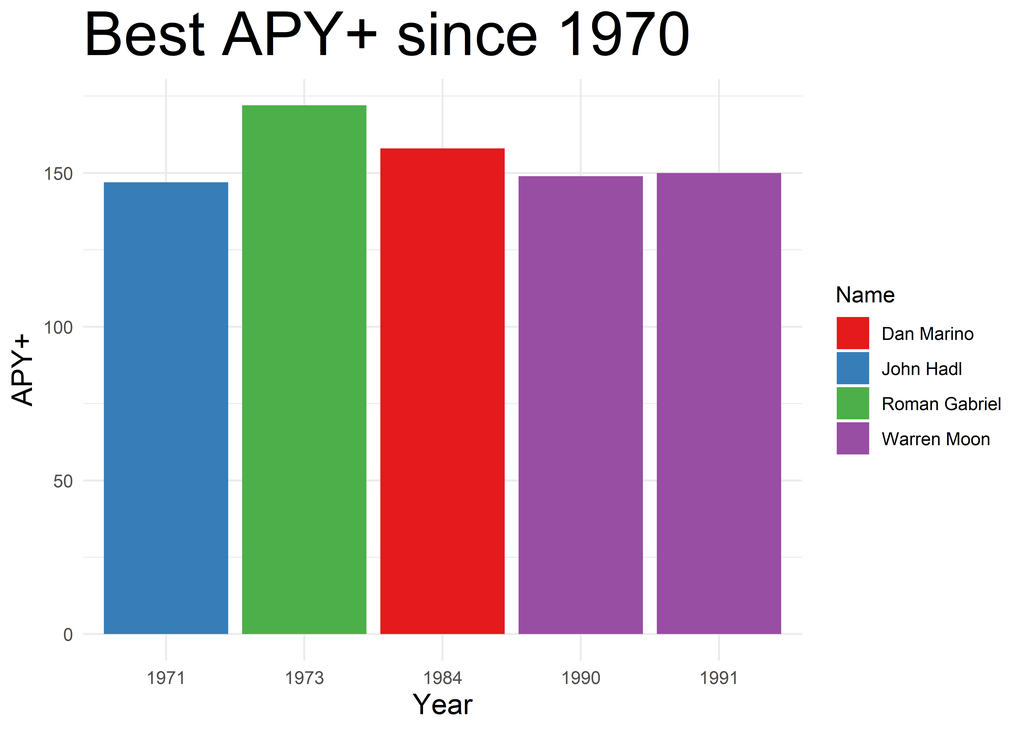

```r
#Creates best APY+ visualization
ggplot(head(AdjYardTable, 5)) +
  aes(x = Year, y = `APY+`, fill = Player) +
  geom_col() +
  scale_fill_brewer(palette = "Set1", direction = 1) +
  labs(
    x = "Year",
    y = "APY+",
    title = "Best APY+ since 1970",
    fill = "Name"
  ) +
  theme_minimal() +
  theme(
    plot.title = element_text(size = 30L),
    axis.title.y = element_text(size = 14L),
    axis.title.x = element_text(size = 14L)
  )
```

### Average Points+

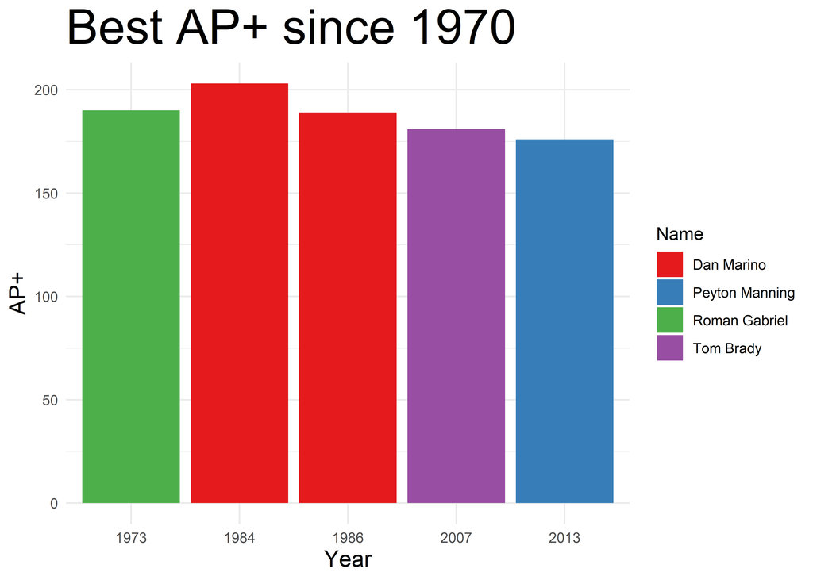

```r
#Creates Visualization for AP+
ggplot(head(AdjPointTable, 5)) +
  aes(x = Year, y = `AP+`, fill = Player) +
  geom_col() +
  scale_fill_brewer(palette = "Set1", direction = 1) +
  labs(
    x = "Year",
    y = "AP+",
    title = "Best AP+ since 1970",
    fill = "Name"
  ) +
  theme_minimal() +
  theme(
    plot.title = element_text(size = 30L),
    axis.title.y = element_text(size = 14L),
    axis.title.x = element_text(size = 14L)
  )
```